# Linear model

## Content

1. The linear model `lm()`
2. Simple regression
3. Multiple regression

## Linear Model

The linear regression model:

\[y_i=\beta_0+\sum_{j}\beta_{j} x_{ij}+\varepsilon_i, \ \ \ \ \ \ \varepsilon_i\sim N(0, \sigma^2)\] where

- \(y_i\) is score of individual \(i\) on the numeric dependent variable \(Y\)
- \(x_{ij}\) is the score of individual \(i\) on predictor \(X_j\)
- \(\beta_0\) is the intercept
- \(\beta_j\) is the slope of \(X_j\)
- \(\varepsilon_{i}\) is the residual (prediction error)

## The `lm()` function

```r
lm(formula, data) # returns an object of class lm
```

| formula | model |
| --- | --- |
| `y ~ 1` | intercept-only |
| `y ~ x1` | main effect of x1 |
| `y ~ x1 + x2` | main effects of x1, x2 |
| `y ~ .` | main effects of all predictors |
| `y ~ . - x1` | main effects of all predictors except x1 |
| `y ~ x1 + x2 + x1:x2` | main effects + interaction between x1 and x2 |
| `y ~ x1*x2` | idem |
| `y ~ .^2` | main effects + pairwise interactions between all predictors |

## Simple regression

## Continuous predictor

- observed = fitted + residual

\[y_i=\hat{y}_i+\varepsilon_i\] - fitted = intercept + slope times x

\[\hat{y}_i=\beta_0 + \beta_1x_i\]

- fitted changes with \(\beta_1\) for each unit increase in \(x\)

## Regression line for `mpg ~ disp`

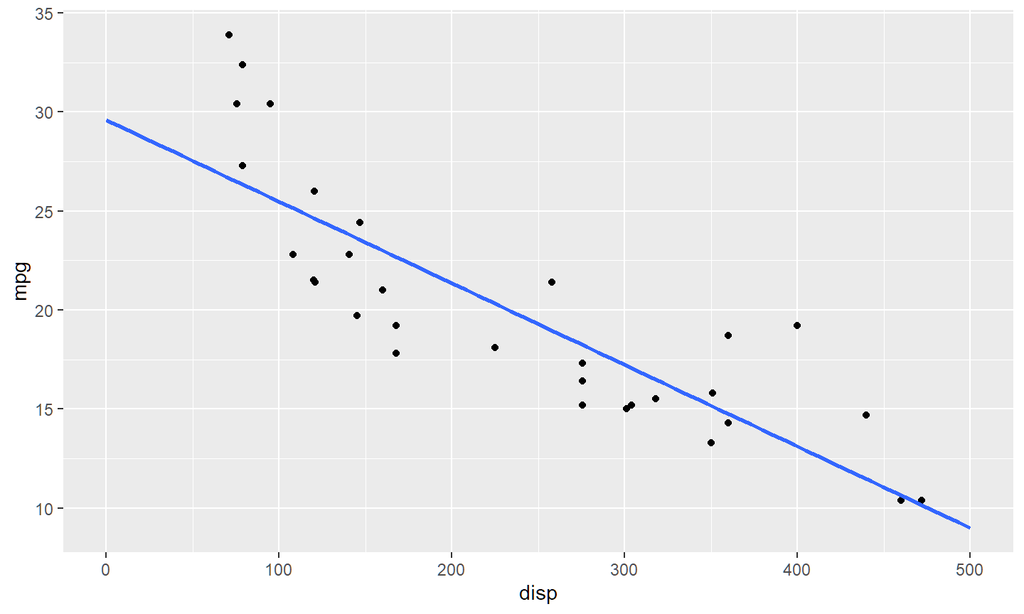

```r
ggplot(mtcars, aes(disp, mpg)) +
  geom_point() +
  xlim(0, 500) +
  geom_smooth(method = "lm", se = FALSE, fullrange=T)
```

## Coefficients

Interpretation the parameter estimates.

```r
(fit <- lm(mpg ~ disp, mtcars))
```

```
Call:
lm(formula = mpg ~ disp, data = mtcars)

Coefficients:
(Intercept)         disp
   29.59985     -0.04122
```

## Structure of `lm` object

```r
str(fit)
```

```
List of 12
 $ coefficients : Named num [1:2] 29.5999 -0.0412
  ..- attr(*, "names")= chr [1:2] "(Intercept)" "disp"
 $ residuals    : Named num [1:32] -2.01 -2.01 -2.35 2.43 3.94 ...
  ..- attr(*, "names")= chr [1:32] "Mazda RX4" "Mazda RX4 Wag" "Datsun 710" "Hornet 4 Drive" ...
 $ effects      : Named num [1:32] -113.65 -28.44 -1.79 2.65 3.92 ...
  ..- attr(*, "names")= chr [1:32] "(Intercept)" "disp" "" "" ...
 $ rank         : int 2
 $ fitted.values: Named num [1:32] 23 23 25.1 19 14.8 ...
  ..- attr(*, "names")= chr [1:32] "Mazda RX4" "Mazda RX4 Wag" "Datsun 710" "Hornet 4 Drive" ...
 $ assign       : int [1:2] 0 1
 $ qr           :List of 5
  ..$ qr   : num [1:32, 1:2] -5.657 0.177 0.177 0.177 0.177 ...
  .. ..- attr(*, "dimnames")=List of 2
  .. .. ..$ : chr [1:32] "Mazda RX4" "Mazda RX4 Wag" "Datsun 710" "Hornet 4 Drive" ...
  .. .. ..$ : chr [1:2] "(Intercept)" "disp"
  .. ..- attr(*, "assign")= int [1:2] 0 1
  ..$ qraux: num [1:2] 1.18 1.09
  ..$ pivot: int [1:2] 1 2
  ..$ tol  : num 1e-07
  ..$ rank : int 2
  ..- attr(*, "class")= chr "qr"
 $ df.residual  : int 30
 $ xlevels      : Named list()
 $ call         : language lm(formula = mpg ~ disp, data = mtcars)
 $ terms        :Classes 'terms', 'formula'  language mpg ~ disp
  .. ..- attr(*, "variables")= language list(mpg, disp)
  .. ..- attr(*, "factors")= int [1:2, 1] 0 1
  .. .. ..- attr(*, "dimnames")=List of 2
  .. .. .. ..$ : chr [1:2] "mpg" "disp"
  .. .. .. ..$ : chr "disp"
  .. ..- attr(*, "term.labels")= chr "disp"
  .. ..- attr(*, "order")= int 1
  .. ..- attr(*, "intercept")= int 1
  .. ..- attr(*, "response")= int 1
  .. ..- attr(*, ".Environment")=<environment: R_GlobalEnv>
  .. ..- attr(*, "predvars")= language list(mpg, disp)
  .. ..- attr(*, "dataClasses")= Named chr [1:2] "numeric" "numeric"
  .. .. ..- attr(*, "names")= chr [1:2] "mpg" "disp"
 $ model        :'data.frame':  32 obs. of  2 variables:
  ..$ mpg : num [1:32] 21 21 22.8 21.4 18.7 18.1 14.3 24.4 22.8 19.2 ...
  ..$ disp: num [1:32] 160 160 108 258 360 ...
  ..- attr(*, "terms")=Classes 'terms', 'formula'  language mpg ~ disp
  .. .. ..- attr(*, "variables")= language list(mpg, disp)
  .. .. ..- attr(*, "factors")= int [1:2, 1] 0 1
  .. .. .. ..- attr(*, "dimnames")=List of 2
  .. .. .. .. ..$ : chr [1:2] "mpg" "disp"
  .. .. .. .. ..$ : chr "disp"
  .. .. ..- attr(*, "term.labels")= chr "disp"
  .. .. ..- attr(*, "order")= int 1
  .. .. ..- attr(*, "intercept")= int 1
  .. .. ..- attr(*, "response")= int 1
  .. .. ..- attr(*, ".Environment")=<environment: R_GlobalEnv>
  .. .. ..- attr(*, "predvars")= language list(mpg, disp)
  .. .. ..- attr(*, "dataClasses")= Named chr [1:2] "numeric" "numeric"
  .. .. .. ..- attr(*, "names")= chr [1:2] "mpg" "disp"
 - attr(*, "class")= chr "lm"
```

## Summary of `lm` object

```r
summary(fit)
```

```
Call:
lm(formula = mpg ~ disp, data = mtcars)

Residuals:
    Min      1Q  Median      3Q     Max
-4.8922 -2.2022 -0.9631  1.6272  7.2305

Coefficients:
             Estimate Std. Error t value Pr(>|t|)
(Intercept) 29.599855   1.229720  24.070  < 2e-16 ***
disp        -0.041215   0.004712  -8.747 9.38e-10 ***
---
Signif. codes:  0 '***' 0.001 '**' 0.01 '*' 0.05 '.' 0.1 ' ' 1

Residual standard error: 3.251 on 30 degrees of freedom
Multiple R-squared:  0.7183,    Adjusted R-squared:  0.709
F-statistic: 76.51 on 1 and 30 DF,  p-value: 9.38e-10
```

## Structure summary `lm` object

```r
str(summary(fit))
```

```
List of 11
 $ call         : language lm(formula = mpg ~ disp, data = mtcars)
 $ terms        :Classes 'terms', 'formula'  language mpg ~ disp
  .. ..- attr(*, "variables")= language list(mpg, disp)
  .. ..- attr(*, "factors")= int [1:2, 1] 0 1
  .. .. ..- attr(*, "dimnames")=List of 2
  .. .. .. ..$ : chr [1:2] "mpg" "disp"
  .. .. .. ..$ : chr "disp"
  .. ..- attr(*, "term.labels")= chr "disp"
  .. ..- attr(*, "order")= int 1
  .. ..- attr(*, "intercept")= int 1
  .. ..- attr(*, "response")= int 1
  .. ..- attr(*, ".Environment")=<environment: R_GlobalEnv>
  .. ..- attr(*, "predvars")= language list(mpg, disp)
  .. ..- attr(*, "dataClasses")= Named chr [1:2] "numeric" "numeric"
  .. .. ..- attr(*, "names")= chr [1:2] "mpg" "disp"
 $ residuals    : Named num [1:32] -2.01 -2.01 -2.35 2.43 3.94 ...
  ..- attr(*, "names")= chr [1:32] "Mazda RX4" "Mazda RX4 Wag" "Datsun 710" "Hornet 4 Drive" ...
 $ coefficients : num [1:2, 1:4] 29.59985 -0.04122 1.22972 0.00471 24.07041 ...
  ..- attr(*, "dimnames")=List of 2
  .. ..$ : chr [1:2] "(Intercept)" "disp"
  .. ..$ : chr [1:4] "Estimate" "Std. Error" "t value" "Pr(>|t|)"
 $ aliased      : Named logi [1:2] FALSE FALSE
  ..- attr(*, "names")= chr [1:2] "(Intercept)" "disp"
 $ sigma        : num 3.25
 $ df           : int [1:3] 2 30 2
 $ r.squared    : num 0.718
 $ adj.r.squared: num 0.709
 $ fstatistic   : Named num [1:3] 76.5 1 30
  ..- attr(*, "names")= chr [1:3] "value" "numdf" "dendf"
 $ cov.unscaled : num [1:2, 1:2] 1.43e-01 -4.85e-04 -4.85e-04 2.10e-06
  ..- attr(*, "dimnames")=List of 2
  .. ..$ : chr [1:2] "(Intercept)" "disp"
  .. ..$ : chr [1:2] "(Intercept)" "disp"
 - attr(*, "class")= chr "summary.lm"
```

## Extracting `lm` list elements:

| Function / Subsetting | Output |
| --- | --- |
| `coef(fit) / fit$coef` | coefficients |
| `fitted(fit) / fit$fitted` | fitted values |
| `resid(fit) / fit$resid` | residuals |
| `summary(fit)$r.squared` | R-squared statistic |

```r
fit$coef
(Intercept)        disp
29.59985476 -0.04121512
summary(fit)$r.squared
[1] 0.7183433
```

## Categorical predictor

## Dummy variables

Categorical predictors are converted into dummy variables:

- each category has a dummy with value 1 for that category, and 0 otherwise
- except for the reference category (0 on all dummies)
- all categories are compared to the reference category

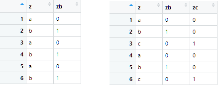

Reference category of \(z\) is \(a\)

## Interpreting dummies

Model for categorical \(Z\) with categories \(a, b, c\):

\[\hat{y}=\beta_0+\beta_1zb+\beta_2zc\]

| parameters | interpretation |
| --- | --- |
| \(\beta_0\) | predicted mean category \(a\) (reference category) |
| \(\beta_0+\beta_1\) | predicted mean category \(b\) |
| \(\beta_0+\beta_2\) | predicted mean category \(c\) |

## Example

Interpret the parameter estimates of model `mpg ~ factor(am)`

- `am = 0` is automatic and `am = 1` is manual transmission
- reference category is `am = 0`

```r
coef(lm(mpg ~ factor(am), mtcars))
```

```
(Intercept) factor(am)1
  17.147368    7.244939
```

## Regression line

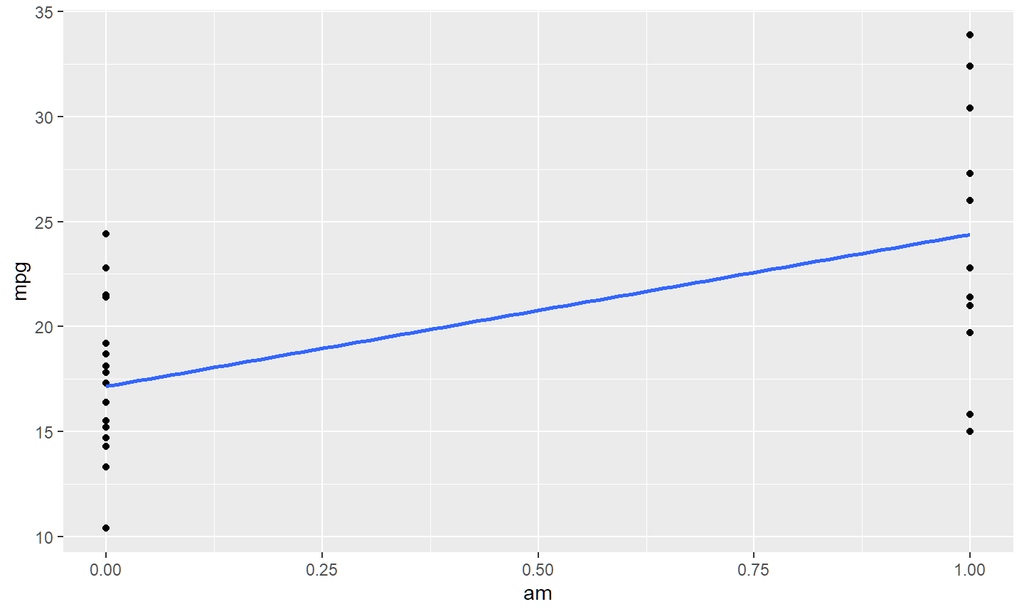

```r
ggplot(mtcars, aes(am, mpg)) +
  geom_point() +
  geom_smooth(method = "lm", se = FALSE)
```

## Predictor `gear` with 3 categories

Works the same as above, but one more dummy needed

- linear model with 2 dummies
- reference category `gear = 3`

```r
lm(mpg ~ factor(gear), mtcars)
```

```
Call:
lm(formula = mpg ~ factor(gear), data = mtcars)

Coefficients:
  (Intercept)  factor(gear)4  factor(gear)5
       16.107          8.427          5.273
```

## Regression lines

Two regression lines

- one from reference 3 gears to 4 gears
- one from reference 3 gears to 5 gears

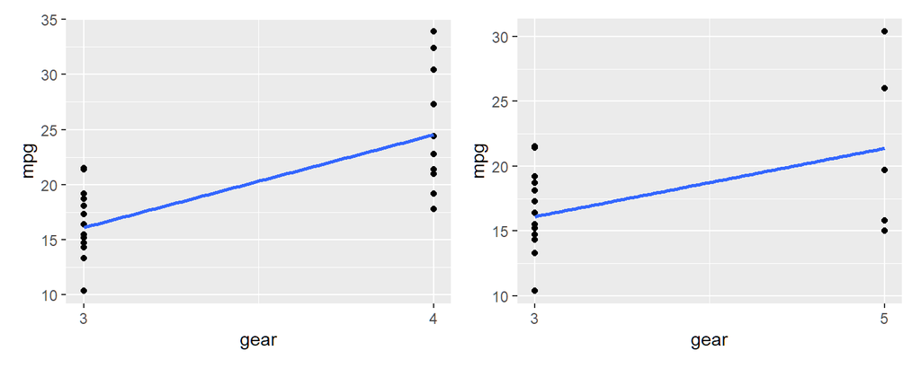

## Factor or not?

The model `mpg ~ gear` interprets the number of gears as numeric

- only one slope is estimated

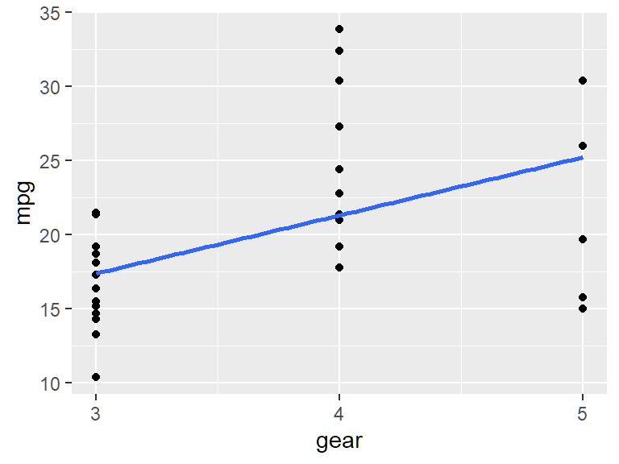

## Model comparisons with `anova()`

Which model fits better:

1. `mpg ~ gear`
2. `mpg ~ factor(gear)`

Model 2 has one more parameter, so it is expected to fit better.

- But is it significantly better?

We can check this with an \(F\)-test for the \(R^2\)-change

- The function to do this test is `anova(model 1, model 2)`

## ANOVA

Compare the fit of the models:

- `mpg ~ 1`
- `mpg ~ gear`
- `mpg ~ factor(gear)`

```r
anova(lm(mpg ~ 1, mtcars),
      lm(mpg ~ gear, mtcars),
      lm(mpg ~ factor(gear), mtcars))
```

```
Analysis of Variance Table

Model 1: mpg ~ 1
Model 2: mpg ~ gear
Model 3: mpg ~ factor(gear)
  Res.Df    RSS Df Sum of Sq      F   Pr(>F)
1     31 1126.0
2     30  866.3  1    259.75 11.719 0.001864 **
3     29  642.8  1    223.49 10.083 0.003534 **
---
Signif. codes:  0 '***' 0.001 '**' 0.01 '*' 0.05 '.' 0.1 ' ' 1
```

## Multiple regression

## Main-effects model

No interactions in the model, e.g.

\[\hat{y}=\beta_0+\beta_1x_1+\beta_2x_2\]

Interpretation

- the slope of \(x_1\) does not depend on \(x_2\), and vice versa
- the slopes of \(x_1\) and \(x_2\) are corrected for the correlation \(r_{x_1,x_2}\)

## Model with `disp` and `gear`

```r
lm(mpg ~ disp, mtcars)$coef %>% round(3)

lm(mpg ~ gear, mtcars)$coef %>% round(3)

lm(mpg ~ disp + gear, mtcars)$coef %>% round(3)
```

```
(Intercept)        disp
     29.600      -0.041
(Intercept)        gear
      5.623       3.923
(Intercept)        disp        gear
     29.105      -0.041       0.111
```

- The slope of `gear` almost disappeared in the last model.

## Interactions

The slope of one predictor depends on the value of the other

```r
lm(mpg ~ disp * factor(am), mtcars)
```

```
Call:
lm(formula = mpg ~ disp * factor(am), data = mtcars)

Coefficients:
     (Intercept)              disp       factor(am)1  disp:factor(am)1
        25.15706          -0.02758           7.70907          -0.03145
```

## Visualization of the interaction model

There is obviously an interaction

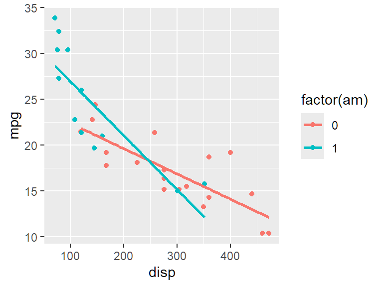

```r
ggplot(mtcars, aes(disp, mpg, col = factor(am))) +
  geom_point() +
  geom_smooth(method = "lm", se=F)
```

## Comparison coefficients

```
           rowname main.effects interaction
1      (Intercept)  27.84808111 25.15706407
2             disp  -0.03685086 -0.02758360
3      factor(am)1   1.83345825  7.70907298
4 disp:factor(am)1           NA -0.03145482
```

## Compare the plots

- Main effects model: same slopes, different intercepts (not visible)
- Interaction model: different slopes and different intercepts

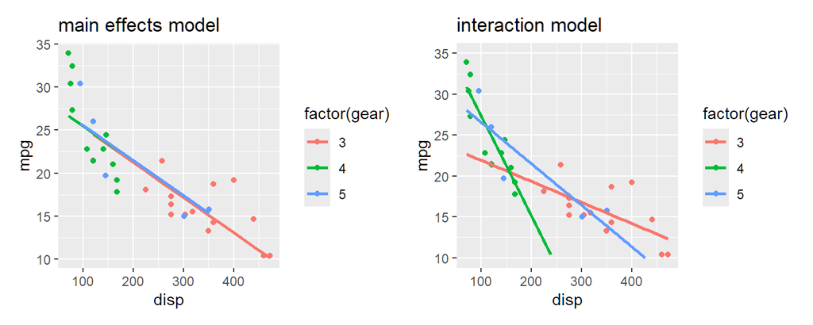

## ANOVA

Compare the fit of the main effects and interaction model

```r
anova(lm(mpg ~ disp + factor(gear), mtcars),
      lm(mpg ~ disp * factor(gear), mtcars))
```

```
Analysis of Variance Table

Model 1: mpg ~ disp + factor(gear)
Model 2: mpg ~ disp * factor(gear)
  Res.Df    RSS Df Sum of Sq      F    Pr(>F)
1     28 317.01
2     26 172.87  2    144.14 10.839 0.0003771 ***
---
Signif. codes:  0 '***' 0.001 '**' 0.01 '*' 0.05 '.' 0.1 ' ' 1
```